# RNA-seq Differential Expression Analysis: Dexamethasone Response in Airway Smooth Muscle

Arjun Babu S B

2026-09-19

## Introduction

This report analyzes RNA-seq data from the `airway` dataset (Himes et al., 2014, *PLoS ONE*): human airway smooth muscle cell lines, some treated with dexamethasone (a glucocorticoid) and some untreated. The goal is to identify genes whose expression changes significantly with treatment, and to interpret those changes biologically.

```r
data(airway)
colData(airway)
```

```
## DataFrame with 8 rows and 9 columns
##            SampleName     cell      dex    albut        Run avgLength
##              <factor> <factor> <factor> <factor>   <factor> <integer>
## SRR1039508 GSM1275862  N61311     untrt    untrt SRR1039508       126
## SRR1039509 GSM1275863  N61311     trt      untrt SRR1039509       126
## SRR1039512 GSM1275866  N052611    untrt    untrt SRR1039512       126
## SRR1039513 GSM1275867  N052611    trt      untrt SRR1039513        87
## SRR1039516 GSM1275870  N080611    untrt    untrt SRR1039516       120
## SRR1039517 GSM1275871  N080611    trt      untrt SRR1039517       126
## SRR1039520 GSM1275874  N061011    untrt    untrt SRR1039520       101
## SRR1039521 GSM1275875  N061011    trt      untrt SRR1039521        98
##            Experiment    Sample    BioSample
##              <factor>  <factor>     <factor>
## SRR1039508  SRX384345 SRS508568 SAMN02422669
## SRR1039509  SRX384346 SRS508567 SAMN02422675
## SRR1039512  SRX384349 SRS508571 SAMN02422678
## SRR1039513  SRX384350 SRS508572 SAMN02422670
## SRR1039516  SRX384353 SRS508575 SAMN02422682
## SRR1039517  SRX384354 SRS508576 SAMN02422673
## SRR1039520  SRX384357 SRS508579 SAMN02422683
## SRR1039521  SRX384358 SRS508580 SAMN02422677
```

## Building the DESeq2 Dataset

Raw counts are combined with sample metadata into a `DESeqDataSet`. The design formula `~ cell + dex` tells DESeq2 to account for baseline differences between the four cell lines, so that only the effect of treatment (`dex`) is tested. Genes with very low counts across all samples are filtered out before analysis, as they carry little information and only add statistical noise.

```r
dds <- DESeqDataSetFromMatrix(
  countData = assay(airway),
  colData   = colData(airway),
  design    = ~ cell + dex
)

keep <- rowSums(counts(dds)) >= 10
dds  <- dds[keep, ]

dds <- estimateSizeFactors(dds)
sizeFactors(dds)
```

```
## SRR1039508 SRR1039509 SRR1039512 SRR1039513 SRR1039516 SRR1039517 SRR1039520
##  1.0236476  0.8961327  1.1795171  0.6700291  1.1776714  1.3990527  0.9208046
## SRR1039521
##  0.9445520
```

## Quality Control

A variance-stabilizing transformation puts genes on a comparable scale before exploratory analysis. PCA and a sample-distance heatmap both check whether samples separate by treatment, independent of the statistical test to come.

```r
vsd <- vst(dds, blind = TRUE)
```

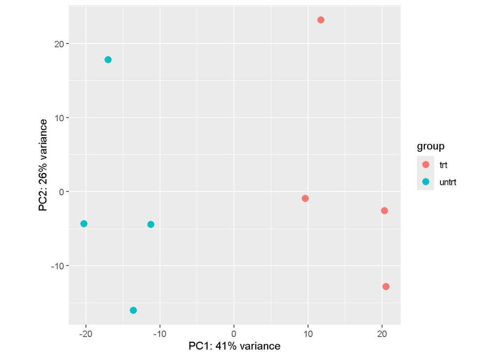

```r
plotPCA(vsd, intgroup = "dex")
```

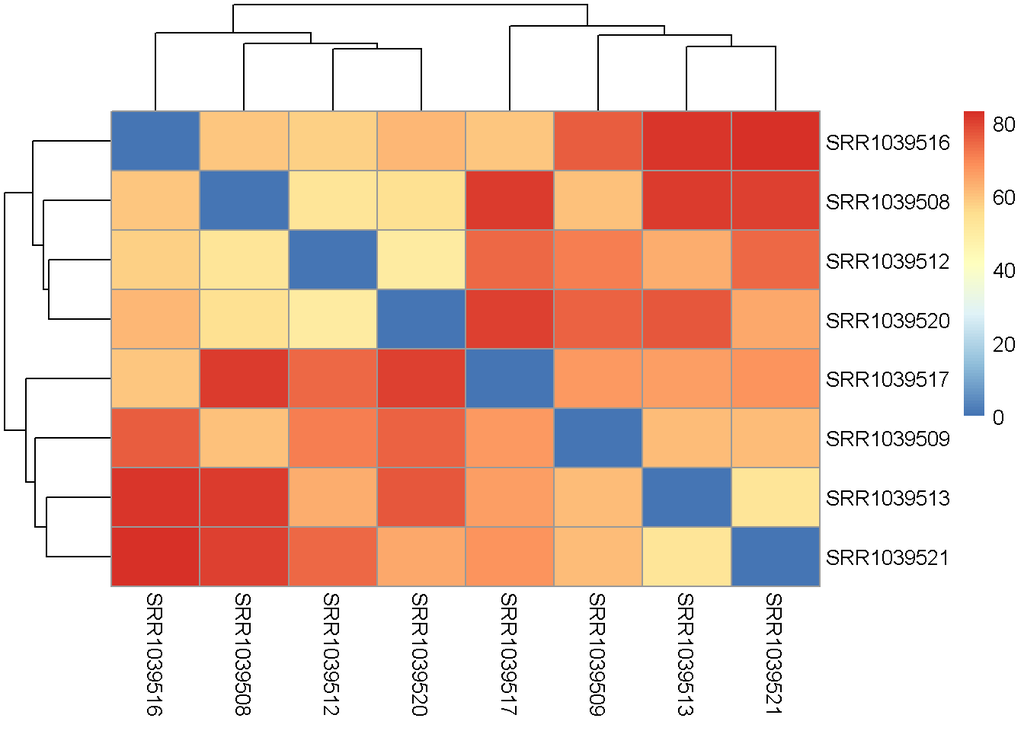

```r
sampleDists      <- dist(t(assay(vsd)))
sampleDistMatrix <- as.matrix(sampleDists)
pheatmap(sampleDistMatrix)
```

Both the PCA and the sample-distance heatmap show samples clustering cleanly by treatment group, indicating that dexamethasone treatment is a dominant source of variation in this dataset.

## Differential Expression Analysis

The reference level is set to `"untrt"` so that results describe the effect of adding dexamethasone, and the full DESeq2 statistical workflow is run.

```r
dds$dex <- relevel(dds$dex, ref = "untrt")
dds     <- DESeq(dds)
res     <- results(dds)
summary(res)
```

```
##
## out of 22369 with nonzero total read count
## adjusted p-value < 0.1
## LFC > 0 (up)       : 2610, 12%
## LFC < 0 (down)     : 2224, 9.9%
## outliers [1]       : 0, 0%
## low counts [2]     : 4337, 19%
## (mean count < 5)
## [1] see 'cooksCutoff' argument of ?results
## [2] see 'independentFiltering' argument of ?results
```

## Volcano Plot

Genes are classified as significantly up- or down-regulated using an adjusted p-value cutoff of 0.05 combined with a minimum 2-fold change (`|log2FoldChange| > 1`), to focus on changes that are both statistically robust and biologically substantial.

```r
res <- res[order(res$padj), ]

res_df      <- as.data.frame(res)
res_df$gene <- rownames(res_df)

res_df$sig <- "Not significant"
res_df$sig[res_df$padj < 0.05 & res_df$log2FoldChange >  1] <- "Up"
res_df$sig[res_df$padj < 0.05 & res_df$log2FoldChange < -1] <- "Down"
```

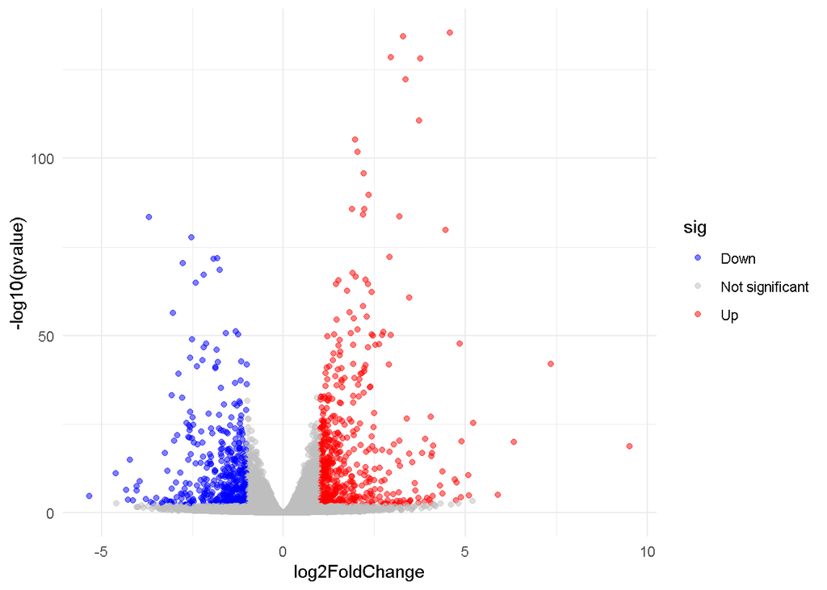

```r
ggplot(res_df, aes(x = log2FoldChange, y = -log10(pvalue), color = sig)) +
  geom_point(alpha = 0.5) +
  scale_color_manual(values = c("Up" = "red", "Down" = "blue",
                                 "Not significant" = "grey")) +
  theme_minimal()
```

## Gene Annotation

Ensembl gene IDs are mapped to readable gene symbols using annotation metadata already bundled with the `airway` package.

```r
gene_symbols <- as.data.frame(rowData(airway))[, c("gene_id", "gene_name")]

res_annotated <- merge(res_df, gene_symbols, by.x = "gene", by.y = "gene_id")
res_annotated <- res_annotated[order(res_annotated$padj), ]

head(res_annotated[, c("gene", "gene_name", "log2FoldChange", "padj")])
```

```
##                  gene gene_name log2FoldChange          padj
## 8109  ENSG00000152583   SPARCL1       4.574967 7.412355e-132
## 9865  ENSG00000165995    CACNB2       3.291099 4.024187e-131
## 4359  ENSG00000120129     DUSP1       2.947850 1.823540e-125
## 2214  ENSG00000101347    SAMHD1       3.767022 3.463342e-125
## 13405 ENSG00000189221      MAOA       3.353655 1.879910e-119
## 14808 ENSG00000211445      GPX3       3.730439 7.768964e-108
```

As a validation check, `CRISPLD2` — the gene highlighted in the title of the original publication — is confirmed as significant and up-regulated in this independently reproduced analysis:

```r
res_annotated[res_annotated$gene_name == "CRISPLD2", ]
```

```
##                 gene baseMean log2FoldChange     lfcSE     stat       pvalue
## 2436 ENSG00000103196 3082.089       2.631298 0.1801105 14.60935 2.448312e-48
##              padj sig gene_name
## 2436 7.883564e-46  Up  CRISPLD2
```

```r
write.csv(res_annotated, "results_DE_annotated.csv", row.names = FALSE)
```

## Heatmap of Top Differentially Expressed Genes

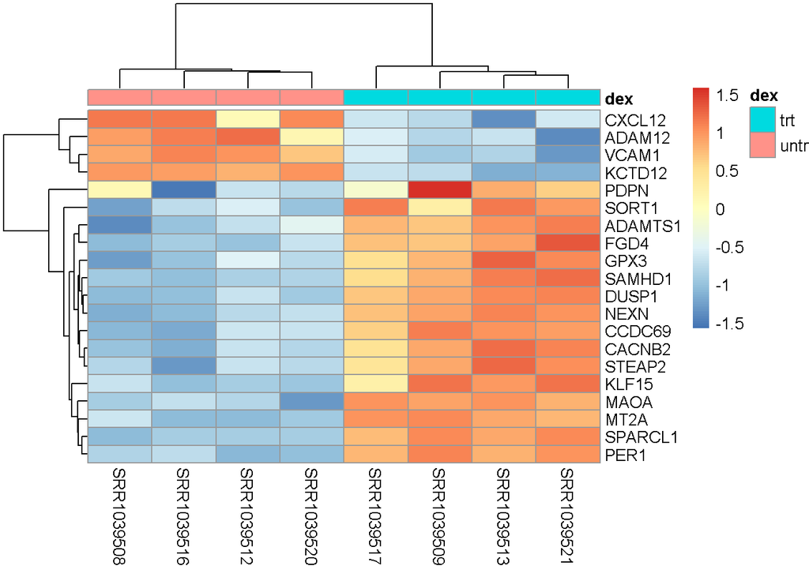

```r
top_hits <- head(res_annotated, 20)
mat      <- assay(vsd)[top_hits$gene, ]
rownames(mat) <- top_hits$gene_name

pheatmap(mat,
         annotation_col = as.data.frame(colData(vsd))["dex"],
         scale = "row")
```

## Pathway Enrichment

Significant genes are tested for enrichment in Gene Ontology (Biological Process) and KEGG pathway categories using `gprofiler2`, which queries gene symbols directly against a public enrichment database.

```r
sig_genes <- res_annotated[res_annotated$sig %in% c("Up", "Down"), ]
gene_list <- sig_genes$gene_name

gostres <- gost(query = gene_list, organism = "hsapiens",
                sources = c("GO:BP", "KEGG"))
```

```r
go_bp <- gostres$result[gostres$result$source == "GO:BP", ]
go_bp_specific <- go_bp[go_bp$term_size < 500, ]
go_bp_specific <- go_bp_specific[order(go_bp_specific$p_value), ]
head(go_bp_specific[, c("term_name", "p_value", "term_size", "intersection_size")])
```

```
##                                        term_name      p_value term_size
## 59             extracellular matrix organization 1.550295e-10       307
## 60          extracellular structure organization 1.739209e-10       308
## 62 external encapsulating structure organization 1.950117e-10       309
## 77                         muscle system process 6.572175e-09       428
## 85                                 axon guidance 2.299293e-08       234
## 89                    neuron projection guidance 2.594632e-08       235
##    intersection_size
## 59                43
## 60                43
## 62                43
## 77                49
## 85                34
## 89                34
```

```r
kegg_hits <- gostres$result[gostres$result$source == "KEGG", ]
kegg_hits <- kegg_hits[order(kegg_hits$p_value), ]
head(kegg_hits[, c("term_name", "p_value", "term_size", "intersection_size")])
```

```
##                                            term_name      p_value term_size
## 357                                    Axon guidance 0.0000440430       183
## 358            Regulation of lipolysis in adipocytes 0.0001009116        59
## 359                     Cytoskeleton in muscle cells 0.0001956575       233
## 360 Inflammatory mediator regulation of TRP channels 0.0008439777        99
## 361                               Pathways in cancer 0.0022818414       530
## 362                              Tyrosine metabolism 0.0076633838        37
##     intersection_size
## 357                27
## 358                14
## 359                30
## 360                17
## 361                49
## 362                 9
```

## Conclusions

- Dexamethasone treatment produces a clear, strong transcriptional response: samples separate cleanly by treatment in both PCA and hierarchical clustering, well before any statistical testing.
- Differential expression testing identifies thousands of significantly affected genes, including `CRISPLD2`, independently reproducing the headline finding of the original publication.
- Pathway enrichment highlights extracellular matrix organization, muscle system processes, and inflammatory signaling — biologically consistent with known glucocorticoid mechanisms in airway smooth muscle.

**Dataset:** Himes BE, et al. (2014) RNA-Seq Transcriptome Profiling Identifies CRISPLD2 as a Glucocorticoid Responsive Gene that Modulates Cytokine Function in Airway Smooth Muscle Cells. *PLoS ONE* 9(6):e99625.